# Walkthrough: mixed data analysis

In this vignette we explore how to use `GSPCR` for the analysis of a data set with a mix of measurement levels. In certain real applications, the dependent variable might be recorded on a continuous numeric scale, while some or all independent variables might be recorded on a binary or even a nominal scale. `GSPCR` supports any combination of these measurement levels.

Let’s start by loading all of the packages we will need.

```r
# Load R packages
library(gspcr)      # this package!
library(superpc)    # alternative comparison package
library(patchwork)  # combining ggplots

# Set a seed
set.seed(20230415)
```

We can then explore the data we will use:

```r
# Look at the helpfile
?GSPCRexdata

# Comment goal of code
X <- GSPCRexdata$X$mix
y <- GSPCRexdata$y$cont
```

# 1 Continuous dependent variable

A standard run of `cv_gspcr` with continuous dependent and indipendent variables can be specified like this:

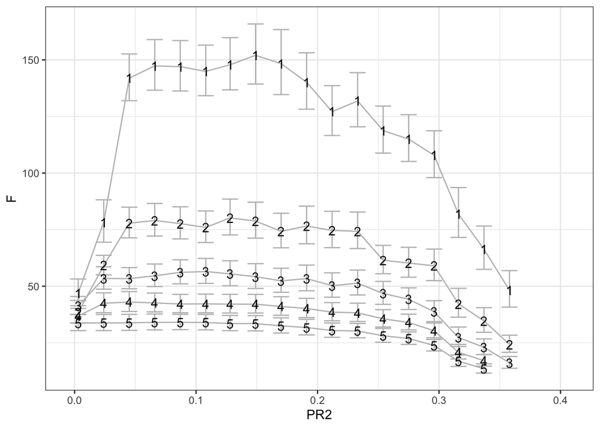

```r
# Train the GSPCR model
out <- cv_gspcr(
  dv = GSPCRexdata$y$cont,
  ivs = GSPCRexdata$X$cont,
  fam = "gaussian",
  nthrs = 20,
  npcs_range = 1:5,
  K = 10,
  fit_measure = "F",
  thrs = "PR2",
  min_features = 1,
  max_features = ncol(X),
  oneSE = TRUE
)

# Use the plotting function
plot_output <- plot(
  x = out,
  y = "F",
  labels = TRUE,
  errorBars = TRUE,
  discretize = FALSE
)

# And plot
plot_output
```

## 1.1 Mix of predictors

However, if it turns out that some of the predictors are discrete (i.e., binary, ordinal, or nominal) `cv_gspcr` will handle them by computing PCA through the PCAmix R package. To explore this scenario, we will run `gspcr` using the continuous dependent variable and the mix of continuous and categorical predictors in the example data set `GSPCRexdata`. As a threshold measure, we cannot use the `normalized` bivariate association used in the original `superpc` R package which requires continuous dependent and independent variables.

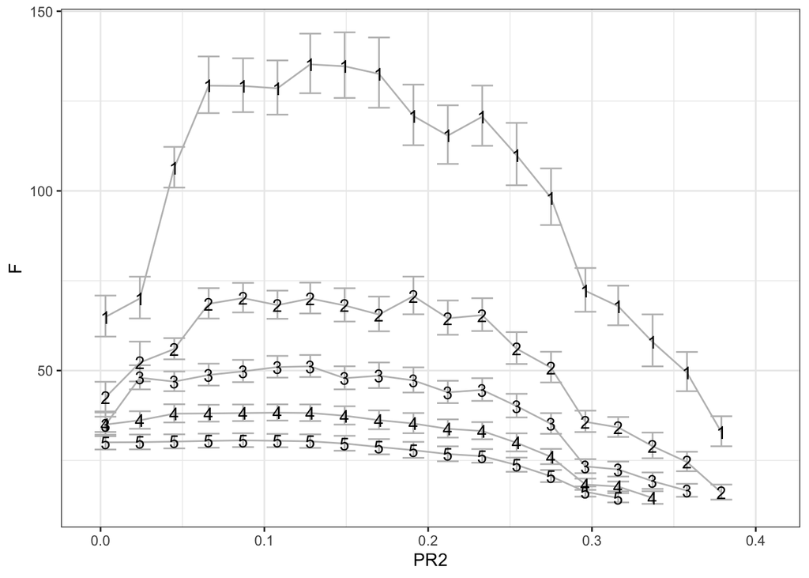

```r
# Train the GSPCR model
out <- cv_gspcr(
  dv = GSPCRexdata$y$cont,
  ivs = GSPCRexdata$X$mix,
  fam = "gaussian",
  nthrs = 20,
  npcs_range = 1:5,
  K = 10,
  fit_measure = "F",
  thrs = "PR2",
  min_features = 1,
  max_features = ncol(X),
  oneSE = TRUE
)

# Use the plotting function
plot_output <- plot(
  x = out,
  y = "F",
  labels = TRUE,
  errorBars = TRUE,
  discretize = FALSE
)

# And plot
plot_output
```

# 2 Ordinal dependent variable

When using a dv with a different measurement level you should change the `fam` argument to match the appropriate GLM family. The fit measure must also match the dependent variable. For more info on which family and which fit measure to use for different dependent variables, see the help file of `cv_gspcr()`.

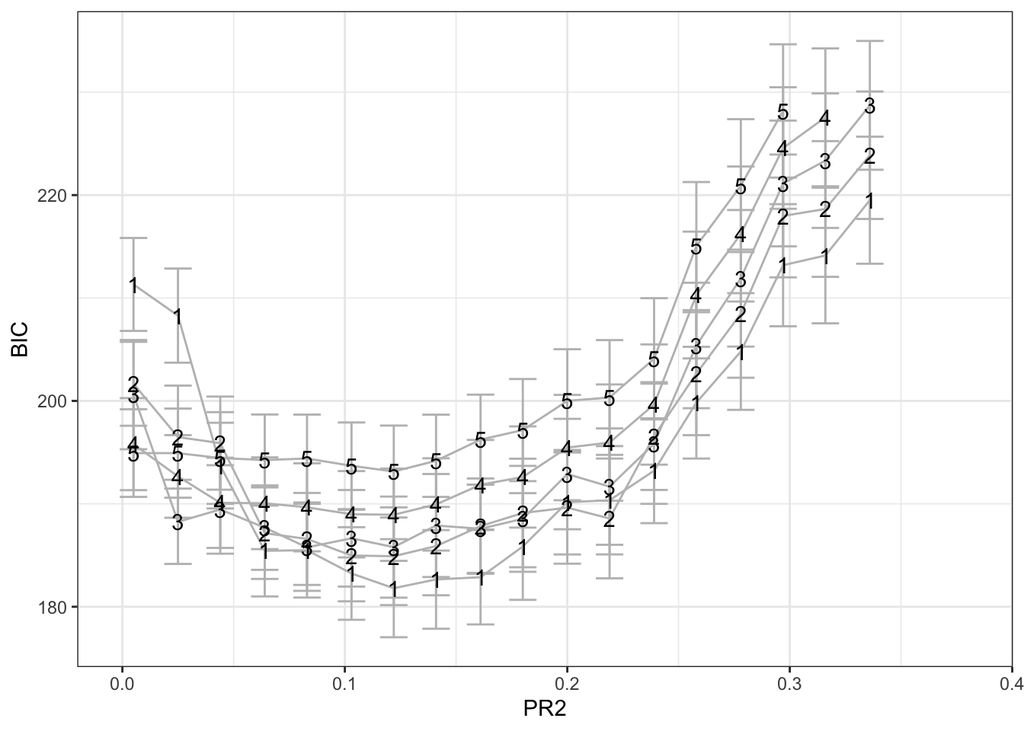

```r
# Train the GSPCR model
out <- cv_gspcr(
  dv = GSPCRexdata$y$ord,
  ivs = GSPCRexdata$X$mix,
  fam = "cumulative",
  nthrs = 20,
  npcs_range = 1:5,
  K = 10,
  fit_measure = "BIC",
  thrs = "PR2",
  min_features = 1,
  max_features = ncol(GSPCRexdata$X$mix),
  oneSE = TRUE
)

# Use the plotting function
plot_output <- plot(
  x = out,
  y = "BIC",
  labels = TRUE,
  errorBars = TRUE,
  discretize = FALSE
)

# And plot
plot_output
```

# 3 Nominal dependent variable

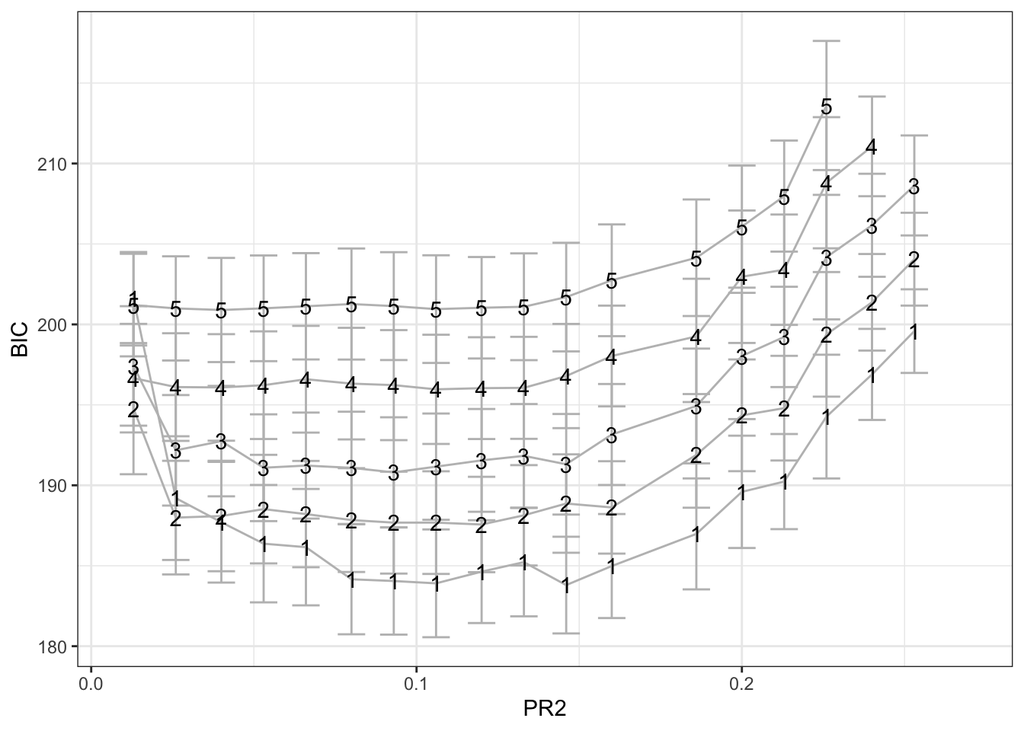

```r
# Train the GSPCR model
out <- cv_gspcr(
  dv = GSPCRexdata$y$cat,
  ivs = GSPCRexdata$X$mix,
  fam = "baseline",
  nthrs = 20,
  npcs_range = 1:5,
  K = 10,
  fit_measure = "BIC",
  thrs = "PR2",
  min_features = 1,
  max_features = ncol(GSPCRexdata$X$mix),
  oneSE = TRUE
)

# Use the plotting function
plot_output <- plot(
  x = out,
  y = "BIC",
  labels = TRUE,
  errorBars = TRUE,
  discretize = FALSE
)

# And plot
plot_output
```

# 4 TL;DR, just give me the code!

```r
# Load R packages
library(gspcr)      # this package!
library(superpc)    # alternative comparison package
library(patchwork)  # combining ggplots

# Set a seed
set.seed(20230415)

# Look at the helpfile
?GSPCRexdata

# Comment goal of code
X <- GSPCRexdata$X$mix
y <- GSPCRexdata$y$cont

# Train the GSPCR model
out <- cv_gspcr(
  dv = GSPCRexdata$y$cont,
  ivs = GSPCRexdata$X$cont,
  fam = "gaussian",
  nthrs = 20,
  npcs_range = 1:5,
  K = 10,
  fit_measure = "F",
  thrs = "PR2",
  min_features = 1,
  max_features = ncol(X),
  oneSE = TRUE
)

# Use the plotting function
plot_output <- plot(
  x = out,
  y = "F",
  labels = TRUE,
  errorBars = TRUE,
  discretize = FALSE
)

# And plot
plot_output

# Train the GSPCR model
out <- cv_gspcr(
  dv = GSPCRexdata$y$cont,
  ivs = GSPCRexdata$X$mix,
  fam = "gaussian",
  nthrs = 20,
  npcs_range = 1:5,
  K = 10,
  fit_measure = "F",
  thrs = "PR2",
  min_features = 1,
  max_features = ncol(X),
  oneSE = TRUE
)

# Use the plotting function
plot_output <- plot(
  x = out,
  y = "F",
  labels = TRUE,
  errorBars = TRUE,
  discretize = FALSE
)

# And plot
plot_output

# Train the GSPCR model
out <- cv_gspcr(
  dv = GSPCRexdata$y$ord,
  ivs = GSPCRexdata$X$mix,
  fam = "cumulative",
  nthrs = 20,
  npcs_range = 1:5,
  K = 10,
  fit_measure = "BIC",
  thrs = "PR2",
  min_features = 1,
  max_features = ncol(GSPCRexdata$X$mix),
  oneSE = TRUE
)

# Use the plotting function
plot_output <- plot(
  x = out,
  y = "BIC",
  labels = TRUE,
  errorBars = TRUE,
  discretize = FALSE
)

# And plot
plot_output

# Train the GSPCR model
out <- cv_gspcr(
  dv = GSPCRexdata$y$cat,
  ivs = GSPCRexdata$X$mix,
  fam = "baseline",
  nthrs = 20,
  npcs_range = 1:5,
  K = 10,
  fit_measure = "BIC",
  thrs = "PR2",
  min_features = 1,
  max_features = ncol(GSPCRexdata$X$mix),
  oneSE = TRUE
)

# Use the plotting function
plot_output <- plot(
  x = out,
  y = "BIC",
  labels = TRUE,
  errorBars = TRUE,
  discretize = FALSE
)

# And plot
plot_output
```